# Graph Tables, Add Labels, Make Notes

Maria Eduarda Mesquita Magalhães

2023-05-29

# 1 Introdução

Vamos carregar as bibliotecas necessárias para o estudo desse capítulo.

```r
library(ggplot2)
library(socviz)
library(dplyr)
```

Algumas definições importantes: - Biblioteca dplyr:fornece uma interface consistente e intuitiva para realizar operações comuns de manipulação de dados, como filtragem, seleção de colunas, ordenação, agrupamento, agregação e criação de variáveis derivada e foi desenvolvida para facilitar a manipulação e transformação de conjuntos de dados (data frames). A principal vantagem do dplyr é sua sintaxe concisa e legível, que permite escrever código mais eficiente e expressivo. Em vez de usar loops ou estruturas de controle complexas, você pode encadear uma sequência de verbos (funções) para realizar transformações nos dados. Isso torna o código mais fácil de escrever, entender e dar manutenção.

- Operador pipe(%>%): é usado para encadear múltiplas operações em uma única sequência. Ele permite que você aplique uma série de transformações em um conjunto de dados sem a necessidade de criar variáveis intermediárias ou escrever várias linhas de código. Ele facilita a leitura e a compreensão do código, pois você pode escrever as transformações em uma ordem lógica, da esquerda para a direita. Cada resultado intermediário é passado automaticamente como o primeiro argumento da próxima função na sequência. Isso elimina a necessidade de atribuir e nomear variáveis temporárias, tornando o código mais conciso e legível.

```r
rel_by_region <- gss_sm %>%
  group_by(bigregion, religion) %>%
  summarize(N=n()) %>%
  mutate(freq=N/sum(N), pct=round((freq*100),0))
```

O código fornecido realiza uma sequência de operações no conjunto de dados gss_sm. - group_by(bigregion, religion): Esta linha agrupa os dados pela macrorregião e religião, ou seja, cria grupos com base nesses dois campos. Isso significa que os cálculos subsequentes serão aplicados a cada combinação única desses dois grupos.

No final dessa sequência, o objeto rel_by_region conterá o resultado da agregação dos dados. Ele terá as colunas bigregion, religion, N, freq e pct.

```r
rel_by_region
```

```
## # A tibble: 24 × 5
## # Groups:   bigregion [4]
##    bigregion religion       N    freq   pct
##    <fct>     <fct>      <int>   <dbl> <dbl>
##  1 Northeast Protestant   158 0.324      32
##  2 Northeast Catholic     162 0.332      33
##  3 Northeast Jewish        27 0.0553      6
##  4 Northeast None         112 0.230      23
##  5 Northeast Other         28 0.0574      6
##  6 Northeast <NA>           1 0.00205     0
##  7 Midwest   Protestant   325 0.468      47
##  8 Midwest   Catholic     172 0.247      25
##  9 Midwest   Jewish         3 0.00432     0
## 10 Midwest   None         157 0.226      23
## # ℹ 14 more rows
```

group_by(bigregion): Essa parte do código agrupa os dados por uma variável chamada “bigregion”. Isso significa que as operações subsequentes serão aplicadas separadamente para cada grupo de “bigregion”.

%>%: Mais uma vez, o operador pipe é usado para encadear outra operação.

summarize(total=sum(pct)): Essa parte do código realiza uma sumarização dos dados dentro de cada grupo. A função summarize() é usada para calcular estatísticas agregadas ou resumidas. Nesse caso, a função sum() é aplicada à coluna “pct” para calcular a soma dos valores dentro de cada grupo. O resultado é atribuído a uma nova coluna chamada “total”.

Portanto, a linha de código em questão agrupa o conjunto de dados “rel_by_region” pela variável “bigregion” e, em seguida, calcula a soma dos valores na coluna “pct” para cada grupo. O resultado final será um novo conjunto de dados que mostra a soma total para cada “bigregion” presente no conjunto de dados original.

```r
rel_by_region %>% group_by(bigregion) %>% summarize(total=sum(pct))
```

```
## # A tibble: 4 × 2
##   bigregion total
##   <fct>     <dbl>
## 1 Northeast   100
## 2 Midwest     101
## 3 South       100
## 4 West        101
```

Agora, vamos testar outras possibilidades:

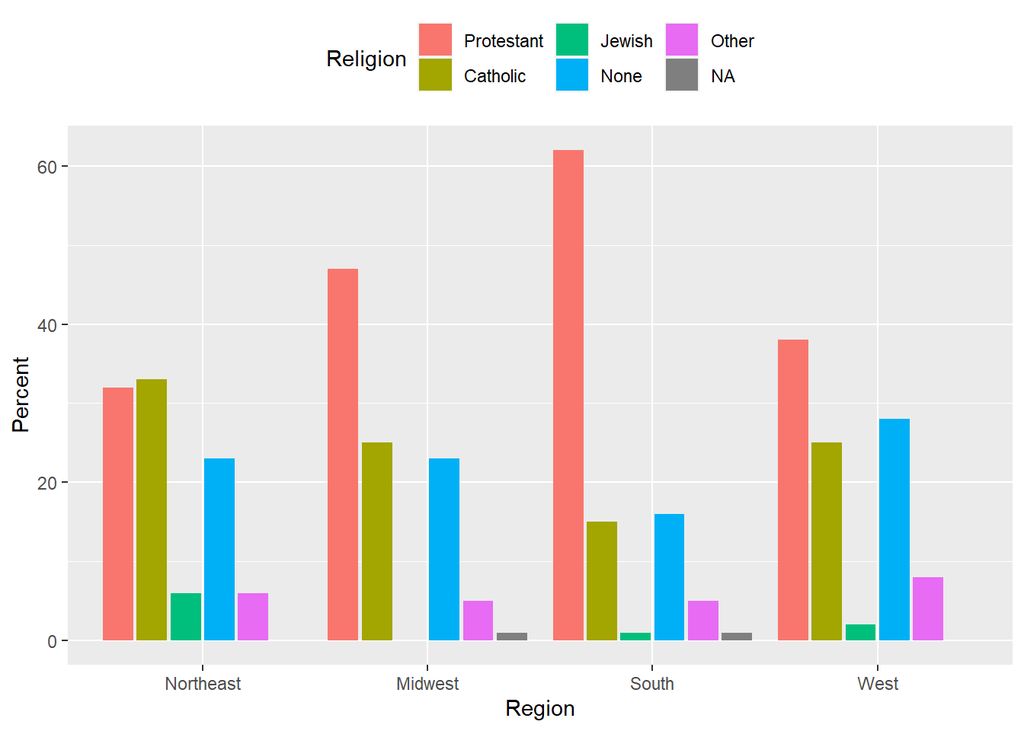

```r
p <- ggplot(rel_by_region, aes(x=bigregion, y=pct, fill=religion))
p+geom_col(position="dodge2") + labs(x="Region", y ="Percent", fill="Religion") +theme(legend.position="top")
```

Usa dodge2 ao invés de dodge coloca as barras uma do lado da outra. Vamos deixar o gráfico visualmente mais agradável e fácil de ler sumarizando tabelas de dados sem ter que escrever códigos gigantes ou usandos muitas funções geométricas.

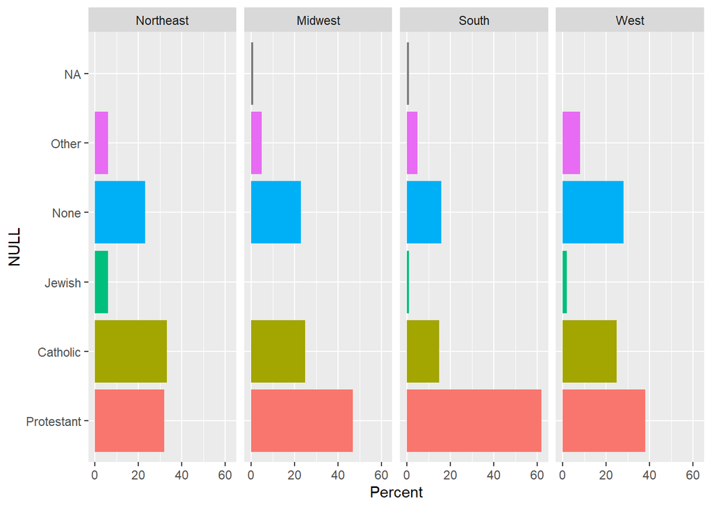

```r
p <- ggplot(rel_by_region, aes(x=religion, y=pct, fill=religion))
p+geom_col(position="dodge2") + labs(x="NULL", y ="Percent", fill="Religion") + guides(fill=FALSE) + coord_flip()+ facet_grid(~bigregion)
```

p <- ggplot(rel_by_region, aes(x=religion, y=pct, fill=religion)) Nesta linha, está sendo criado um objeto p que representa o gráfico base. Está sendo utilizado o conjunto de dados rel_by_region como fonte dos dados. A estética (aesthetics) do gráfico é definida através da função aes(), onde x=religion define a variável a ser usada no eixo x, y=pct define a variável a ser usada no eixo y e fill=religion define a variável a ser usada para preencher as colunas, baseada na variável religion.

p + geom_col(position=“dodge2”) Aqui, está sendo adicionada uma camada (layer) ao objeto p. A função geom_col() é usada para adicionar as colunas ao gráfico. O argumento position=“dodge2” define que as colunas serão agrupadas (dodged) em relação à variável religion. Isso significa que as colunas de cada nível da variável religion serão posicionadas lado a lado.

No geral, o código está criando um gráfico de colunas agrupadas, onde cada grupo de colunas representa uma categoria da variável religion. O gráfico é dividido em facetas com base na variável bigregion, e as colunas são preenchidas com cores diferentes de acordo com a categoria da variável religion. A legenda de preenchimento é removida, e a orientação dos eixos é invertida para colunas horizontais.

# 2 Variáveis contínuas por grupo ou categorias

Vamos mudar a base de dados para novas análises:

```r
organdata %>% select(1:6) %>% sample_n(size=10)
```

```
## # A tibble: 10 × 6
##    country        year       donors    pop pop_dens   gdp
##    <chr>          <date>      <dbl>  <int>    <dbl> <int>
##  1 Australia      1992-01-01   12.4  17495    0.226 17914
##  2 Denmark        1995-01-01   12.9   5233   12.1   22462
##  3 United States  2002-01-01   21.5 288369    2.99  36006
##  4 Finland        1999-01-01   16.5   5166    1.53  23702
##  5 Belgium        2001-01-01   22.2  10287   31.1   27113
##  6 United States  2001-01-01   21.3 285318    2.96  35118
##  7 Norway         2002-01-01   13.7   4538    1.40  35531
##  8 Italy          NA           NA    56719   18.8   17430
##  9 United Kingdom 1993-01-01   13.9  57711   23.8   17952
## 10 United States  NA           NA   249623    2.59  23038
```

Testando ingenuamente tipos de gráficos:

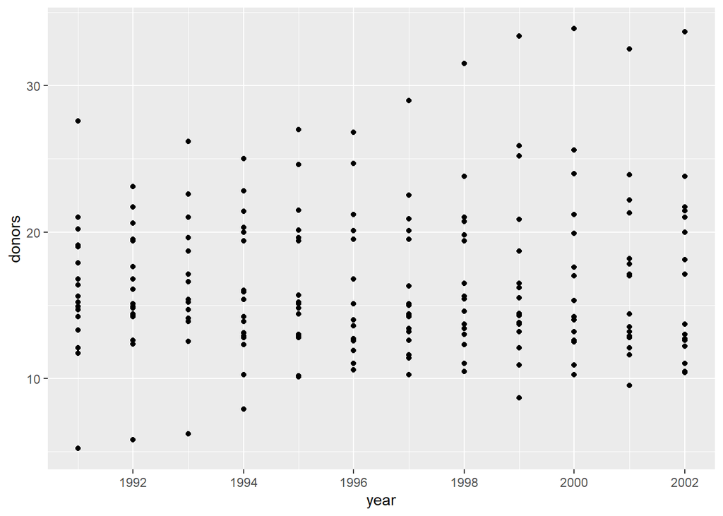

```r
p<-ggplot(data=organdata, mapping=aes(x=year, y=donors))
p+geom_point()
```

Agrupando por país (assim como fizemos no gapminder) e facetando os gráficos por país também, temos:

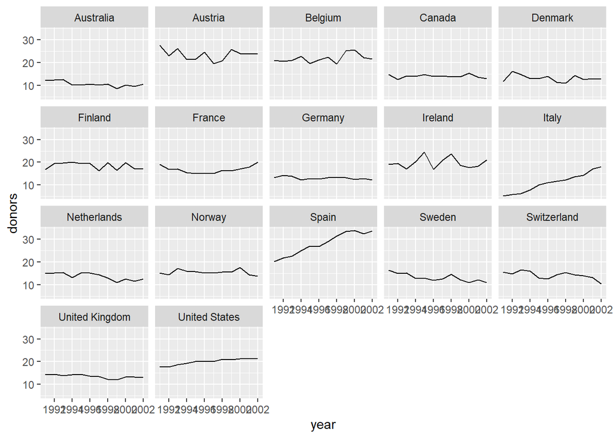

```r
p<- ggplot(data=organdata, mapping = aes(x=year, y=donors))
p+geom_line(aes(group=country))+ facet_wrap(~country)
```

Nós podemos usar a função geométrica box_plot para ter uma noção da variação de doações por ano dos países;

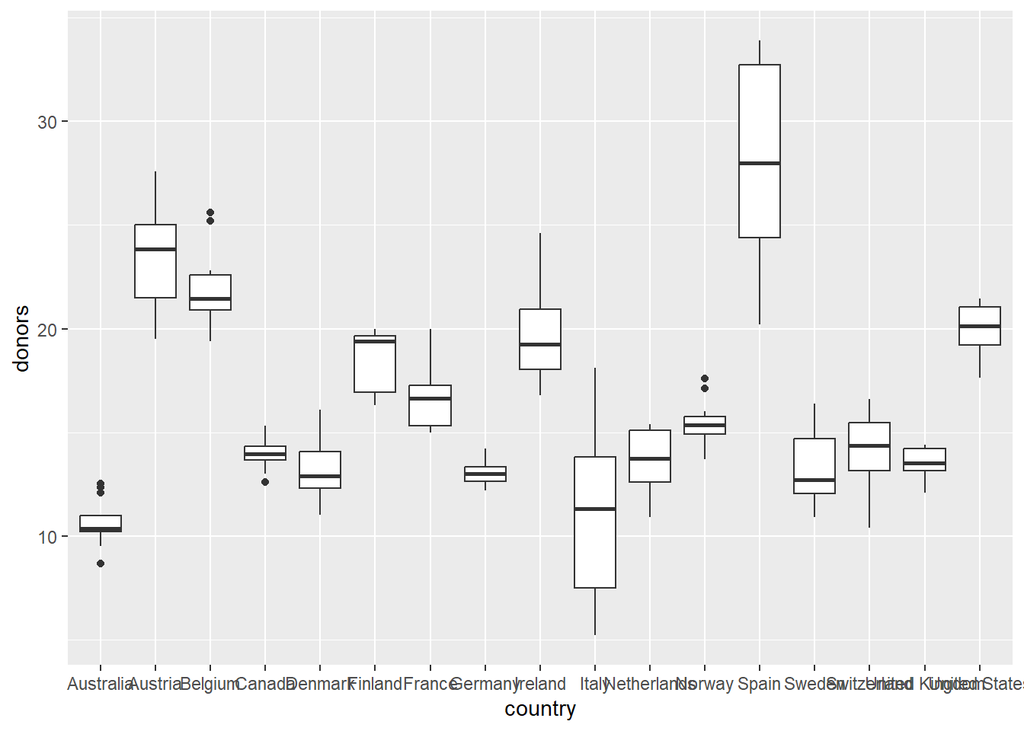

```r
p<-ggplot(data=organdata, mapping=aes(x=country, y=donors))
p+geom_boxplot()
```

Os nomes ficam prensados no eixo x, para resolver isso, vamos reverter as coordenadas:

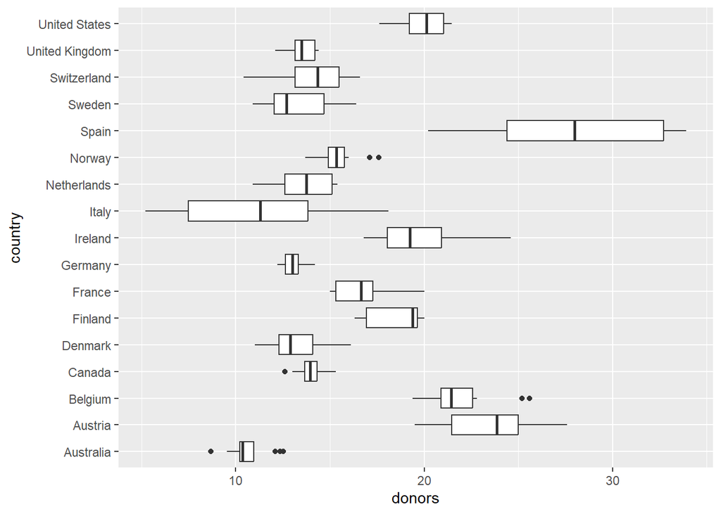

```r
p<-ggplot(data=organdata, mapping=aes(x=country, y=donors))
p+geom_boxplot()+coord_flip()
```

Agora está mais legível, mas ainda não ideal. Vamos colocar os dados em ordem de grandeza:

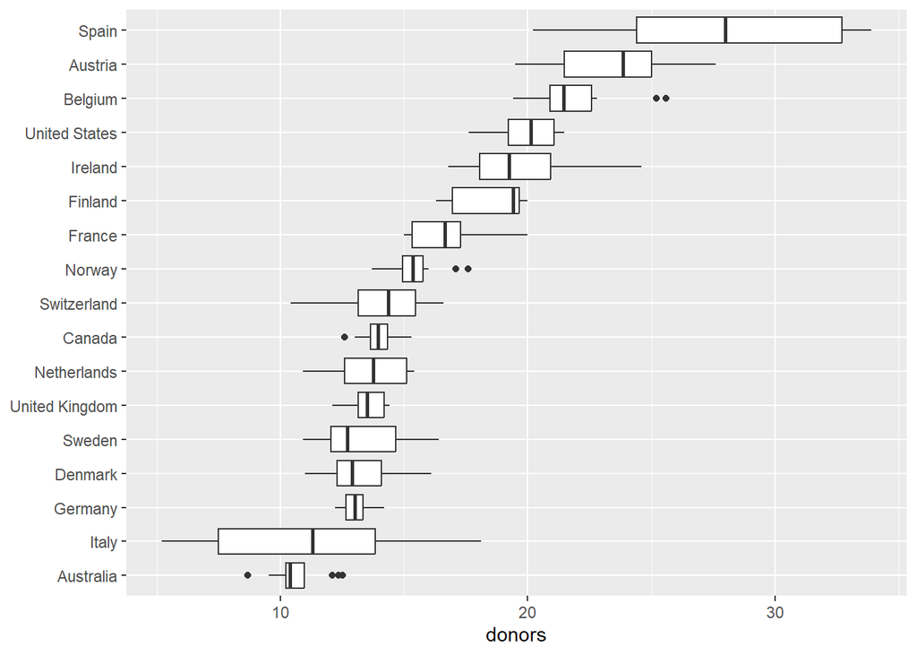

```r
p <-ggplot(data=organdata, mapping = aes(x=reorder(country, donors, na.rm=TRUE), y =donors))
p + geom_boxplot() +labs(x=NULL) + coord_flip()
```

Explicação: p <- ggplot(data=organdata, mapping = aes(x=reorder(country, donors, na.rm=TRUE), y =donors))

Nesta linha, é criado um objeto p que representa o gráfico base. O argumento data=organdata define o conjunto de dados a ser utilizado como fonte dos dados. O argumento mapping especifica a estética (aesthetics) do gráfico. A função aes() é usada para definir as variáveis mapeadas aos eixos x e y do gráfico.

x=reorder(country, donors, na.rm=TRUE) indica que a variável country será mapeada para o eixo x, reordenada com base na variável donors e removendo possíveis valores ausentes (na.rm=TRUE). y=donors define que a variável donors será mapeada para o eixo y.

p + geom_boxplot() Nesta linha, uma camada (layer) de boxplot é adicionada ao objeto p utilizando a função geom_boxplot(). Isso cria os retângulos que representam os quartis, mediana e possíveis outliers dos dados.

- labs(x=NULL) Aqui, é adicionado um rótulo nulo para o eixo x do gráfico, utilizando a função labs() e definindo x=NULL. Isso significa que o rótulo do eixo x será removido do gráfico.
- coord_flip() A função coord_flip() é utilizada para inverter a orientação dos eixos x e y. Isso resulta em um gráfico de boxplot horizontal, com os retângulos dispostos horizontalmente.

Em resumo, o código cria um gráfico de boxplot em que os países são representados no eixo x, reordenados de acordo com a quantidade de doadores (variável donors). O eixo y representa o número de doadores. O gráfico é orientado horizontalmente, e não há rótulo para o eixo x. Isso permite visualizar a distribuição dos doadores em diferentes países e identificar possíveis discrepâncias ou outliers.

Agora, vamos colorir os box plots.

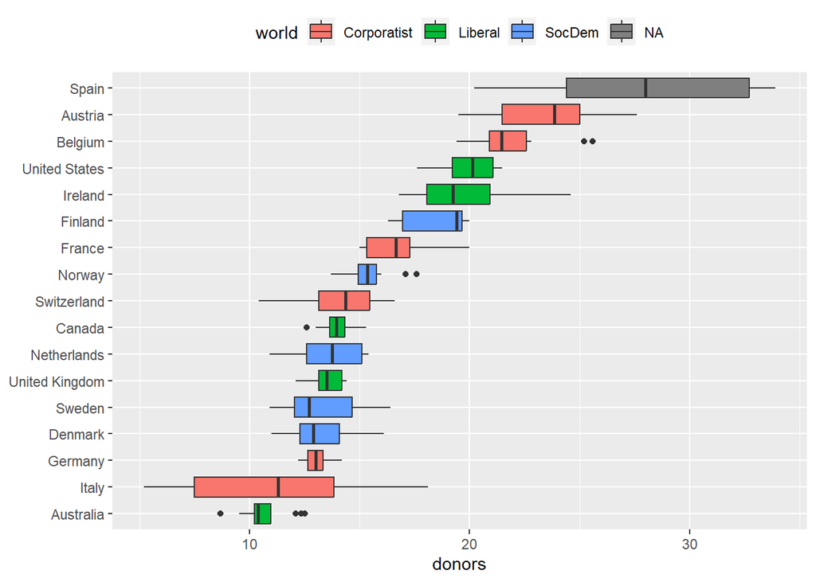

```r
p <- ggplot(data=organdata, mapping = aes(x=reorder(country, donors, na.rm=TRUE), y=donors, fill=world))

p+geom_boxplot()+labs(x=NULL) + coord_flip() +theme(legend.position="top")
```

Enfim, temos um gráfico mais legível e que atrae mais o leitor devido a uma mais eficiente visualização.

Se o número de observações não for muito grande para cada categoria, nós podemos pular os box plots e mostrarmos os pontos individualmente. Desse jeito:

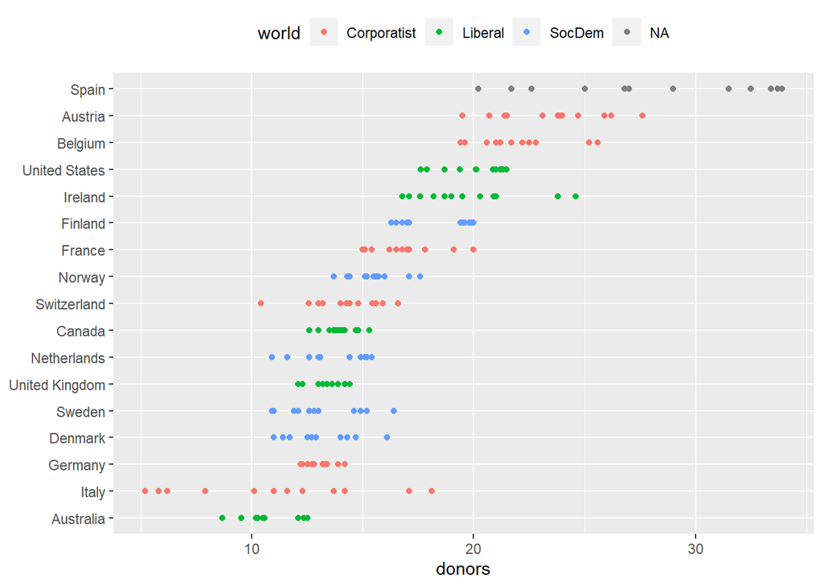

```r
p <- ggplot(data=organdata, mapping = aes(x=reorder(country, donors, na.rm=TRUE), y=donors, color=world))

p+geom_point()+labs(x=NULL) + coord_flip() +theme(legend.position="top")
```

Quando usamos geom_point() assim, há alguma sobreposição de observações. Nesses casos, pode ser útil perturbar um pouco os dados para ter uma noção melhor da variação entre as observações. Usamos geom_jitter() para fazer isso. Este geom mas desloca aleatoriamente cada observação em uma pequena quantidade.

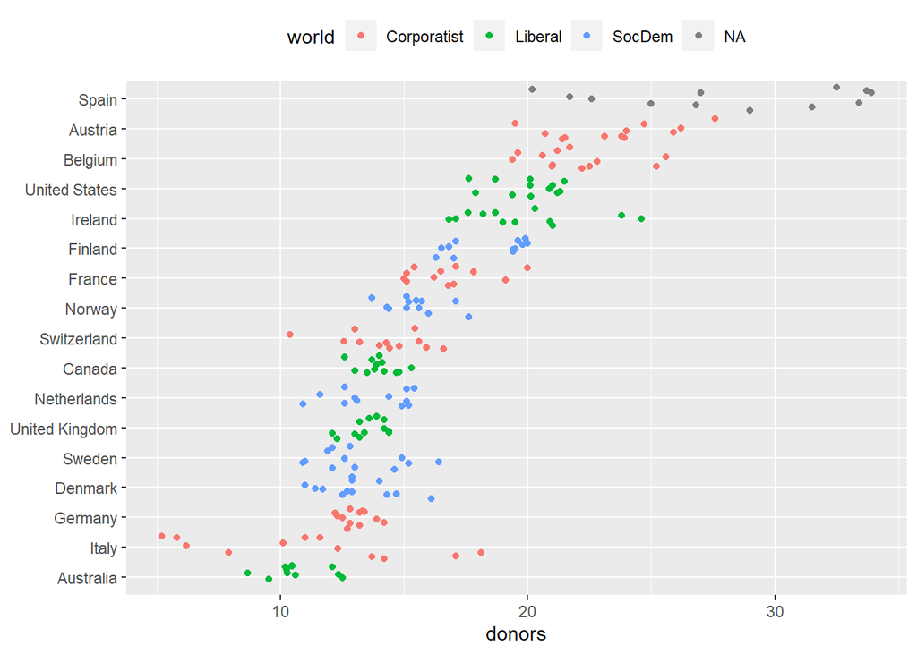

```r
p <- ggplot(data=organdata, mapping = aes(x=reorder(country, donors, na.rm=TRUE), y=donors, color=world))

p+geom_jitter()+labs(x=NULL) + coord_flip() +theme(legend.position="top")
```

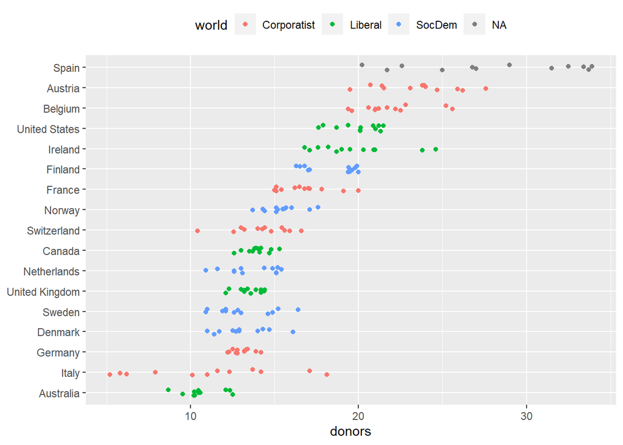

```r
p <- ggplot(data=organdata, mapping = aes(x=reorder(country, donors, na.rm=TRUE), y=donors, color=world))

p+geom_jitter(position=position_jitter(width=0.15))+labs(x=NULL) + coord_flip() +theme(legend.position="top")
```

Explicando: A função aes() é usada para definir as variáveis mapeadas aos eixos x e y do gráfico, x=reorder(country, donors, na.rm=TRUE) indica que a variável country será mapeada para o eixo x, reordenada com base na variável donors e removendo possíveis valores ausentes (na.rm=TRUE). y=donors define que a variável donors será mapeada para o eixo y. Além disso, color=world indica que a variável world será usada para colorir os pontos no gráfico.

- labs(x=NULL) Aqui, é adicionado um rótulo nulo para o eixo x do gráfico, utilizando a função labs() e definindo x=NULL. Isso significa que o rótulo do eixo x será removido do gráfico.
- coord_flip() A função coord_flip() é utilizada para inverter a orientação dos eixos x e y. Isso resulta em um gráfico de dispersão horizontal, com os pontos dispostos horizontalmente.
- theme(legend.position=“top”) Aqui, é aplicado um tema (theme) ao gráfico, definindo a posição da legenda como “top”. Isso significa que a legenda será posicionada no topo do gráfico.

```r
by_country <- organdata %>% group_by(consent_law, country) %>%
  summarize(donors_mean=mean(donors, na.rm=TRUE),
            donors_sd = sd(donors, na.rm=TRUE),
            gdp_mean = mean(gdp, na.rm=TRUE),
            health_mean=mean(health,na.rm=TRUE),
            roads_mean = mean(roads, na.rm=TRUE),
            cerebvas_mean = mean(cerebvas, na.rm=TRUE))
```

No código acima, está sendo criado um novo conjunto de dados chamado by_country, que contém informações resumidas por país e por tipo de legislação de consentimento (consent_law).

%>% group_by(consent_law, country): A função group_by() é aplicada ao conjunto de dados organdata. Ela agrupa os dados pelo tipo de legislação de consentimento (consent_law) e pelo país (country). Isso significa que as operações de resumo serão aplicadas separadamente para cada combinação única desses dois fatores.

summarize(donors_mean = mean(donors, na.rm = TRUE), donors_sd = sd(donors, na.rm = TRUE), gdp_mean = mean(gdp, na.rm = TRUE), health_mean = mean(health, na.rm = TRUE), roads_mean = mean(roads, na.rm = TRUE), cerebvas_mean = mean(cerebvas, na.rm = TRUE)): A função summarize() é aplicada ao conjunto de dados agrupado. Ela calcula várias estatísticas resumidas para as variáveis selecionadas. As estatísticas incluem a média (mean) dos doadores (donors_mean), o desvio padrão (sd) dos doadores (donors_sd), a média do PIB (gdp_mean), a média da saúde (health_mean), a média das estradas (roads_mean) e a média dos vasos cerebrais (cerebvas_mean). O argumento na.rm = TRUE é usado para remover os valores ausentes (missing values) ao calcular as estatísticas.

Após a execução desse código, o objeto by_country será um novo conjunto de dados que contém os valores médios, desvio padrão e médias das variáveis selecionadas, agrupadas por tipo de legislação de consentimento e país.

```r
by_country
```

```
## # A tibble: 17 × 8
## # Groups:   consent_law [2]
##    consent_law country     donors_mean donors_sd gdp_mean health_mean roads_mean
##    <chr>       <chr>             <dbl>     <dbl>    <dbl>       <dbl>      <dbl>
##  1 Informed    Australia          10.6     1.14    22179.       1958.      105.
##  2 Informed    Canada             14.0     0.751   23711.       2272.      109.
##  3 Informed    Denmark            13.1     1.47    23722.       2054.      102.
##  4 Informed    Germany            13.0     0.611   22163.       2349.      113.
##  5 Informed    Ireland            19.8     2.48    20824.       1480.      118.
##  6 Informed    Netherlands        13.7     1.55    23013.       1993.       76.1
##  7 Informed    United Kin…        13.5     0.775   21359.       1561.       67.9
##  8 Informed    United Sta…        20.0     1.33    29212.       3988.      155.
##  9 Presumed    Austria            23.5     2.42    23876.       1875.      150.
## 10 Presumed    Belgium            21.9     1.94    22500.       1958.      155.
## 11 Presumed    Finland            18.4     1.53    21019.       1615.       93.6
## 12 Presumed    France             16.8     1.60    22603.       2160.      156.
## 13 Presumed    Italy              11.1     4.28    21554.       1757       122.
## 14 Presumed    Norway             15.4     1.11    26448.       2217.       70.0
## 15 Presumed    Spain              28.1     4.96    16933        1289.      161.
## 16 Presumed    Sweden             13.1     1.75    22415.       1951.       72.3
## 17 Presumed    Switzerland        14.2     1.71    27233        2776.       96.4
## # ℹ 1 more variable: cerebvas_mean <dbl>
```

```r
by_country <- organdata %>% group_by(consent_law, country) %>%
  summarize_if(is.numeric, funs(mean,sd), na.rm=TRUE) %>%
  ungroup()
```

O código acima cria um novo conjunto de dados chamado by_country a partir do conjunto de dados original organdata. O objetivo é agrupar os dados por tipo de legislação de consentimento (consent_law) e país (country), calcular estatísticas resumidas para as variáveis numéricas e, em seguida, remover o agrupamento.

%>% group_by(consent_law, country): A função group_by() é aplicada ao conjunto de dados organdata. Ela agrupa os dados pelo tipo de legislação de consentimento (consent_law) e pelo país (country).

summarize_if(is.numeric, funs(mean, sd), na.rm = TRUE): A função summarize_if() é aplicada ao conjunto de dados agrupado. Ela seleciona apenas as variáveis numéricas (utilizando is.numeric) e calcula as estatísticas resumidas para essas variáveis. Nesse caso, as estatísticas são a média (mean) e o desvio padrão (sd). O argumento na.rm = TRUE é usado para remover os valores ausentes (missing values) ao calcular as estatísticas.

%>% ungroup(): A função ungroup() é aplicada ao conjunto de dados resultante. Ela remove o agrupamento que foi aplicado anteriormente, retornando o conjunto de dados sem agrupamento.

Após a execução desse código, o objeto by_country será um novo conjunto de dados que contém as estatísticas resumidas (média e desvio padrão) para as variáveis numéricas, agrupadas por tipo de legislação de consentimento e país. O conjunto de dados não estará mais agrupado, permitindo a análise e a visualização dos resumos estatísticos para cada combinação de tipo de legislação de consentimento e país.

Agora, podemos plotar o gráfico:

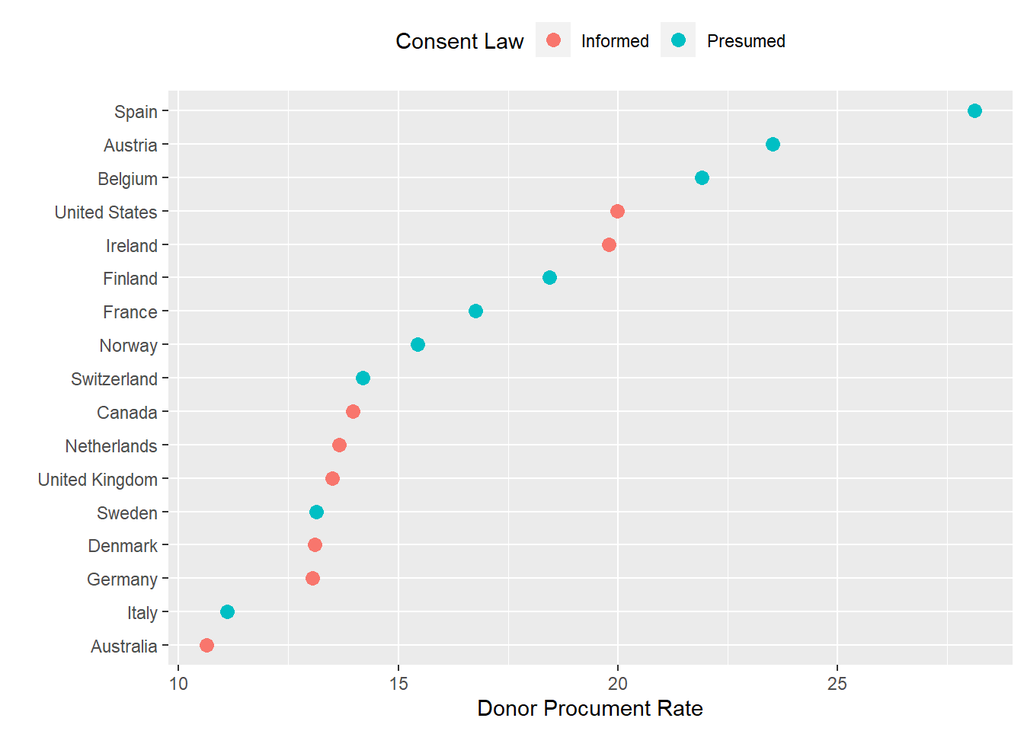

```r
p <- ggplot(data=by_country, mapping=aes(x=donors_mean, y=reorder(country, donors_mean), color=consent_law))

p+geom_point(size=3) + labs(x="Donor Procument Rate", y="", color = "Consent Law") + theme(legend.position="top")
```

Vamos facetar o gráfico ao invés de colorir:

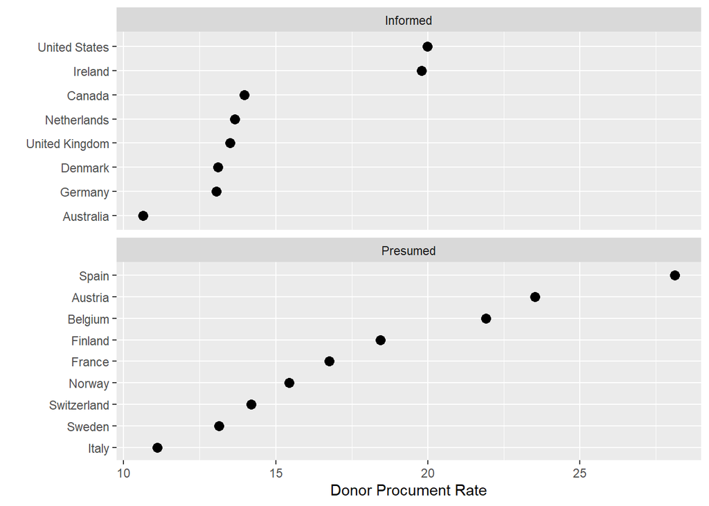

```r
p<- ggplot(data=by_country, mapping=aes(x=donors_mean, y= reorder(country,donors_mean)))

p+geom_point(size=3)+
  facet_wrap(~consent_law, scales="free_y", ncol=1) + labs(x="Donor Procument Rate", y="")
```

Existe um geom chamado geom_dotplot(), mas ele é projetado para produzir um tipo diferente de figura. É uma espécie de histograma, com observações individuais representadas por pontos que são empilhados uns sobre os outros para mostrar quantos deles existem.

Usando geom_pointrange(), podemos dizer ao ggplot para nos mostrar uma estimativa pontual e um intervalo em torno dela. Aqui usaremos o desvio padrão da taxa de doação que calculamos acima. Mas esta também é a forma natural de apresentar, por exemplo, estimativas de coeficientes de modelos com intervalos de confiança. Com geom_pointrange() mapeamos nossas variáveis x e y como de costume, mas a função precisa de um pouco mais de informação do que geom_point. Ele precisa saber o alcance da linha a ser desenhada em cada lado do ponto, definido pelos argumentos ymax e ymin. Isso é dado pelo valor y (donors_mean) mais ou menos seu desvio padrão (donors_sd). Se um argumento de função espera um número, não há problema em fornecer a ele uma expressão matemática que resolva o número desejado. R calculará o resultado para você.

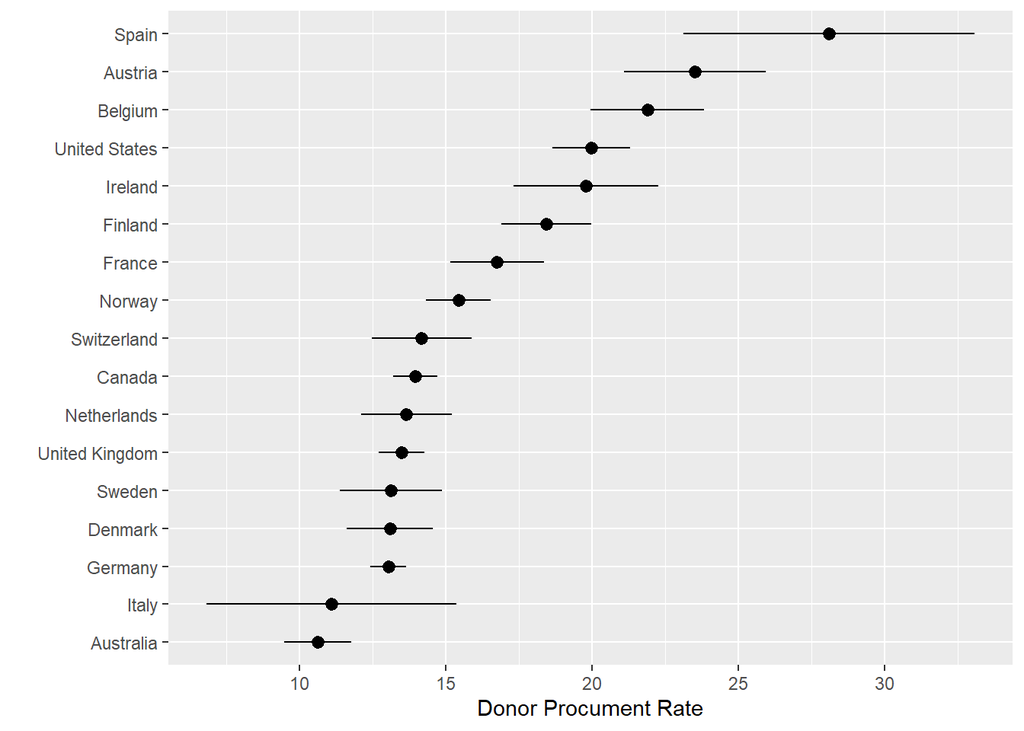

```r
p<- ggplot(data=by_country, mapping=aes(x=reorder(country,donors_mean), y= donors_mean))

p+geom_pointrange(mapping=aes(ymin=donors_mean - donors_sd, ymax= donors_mean + donors_sd))+ labs(x="", y="Donor Procument Rate") + coord_flip()
```

# 3 Plotando os gráficos diretamente

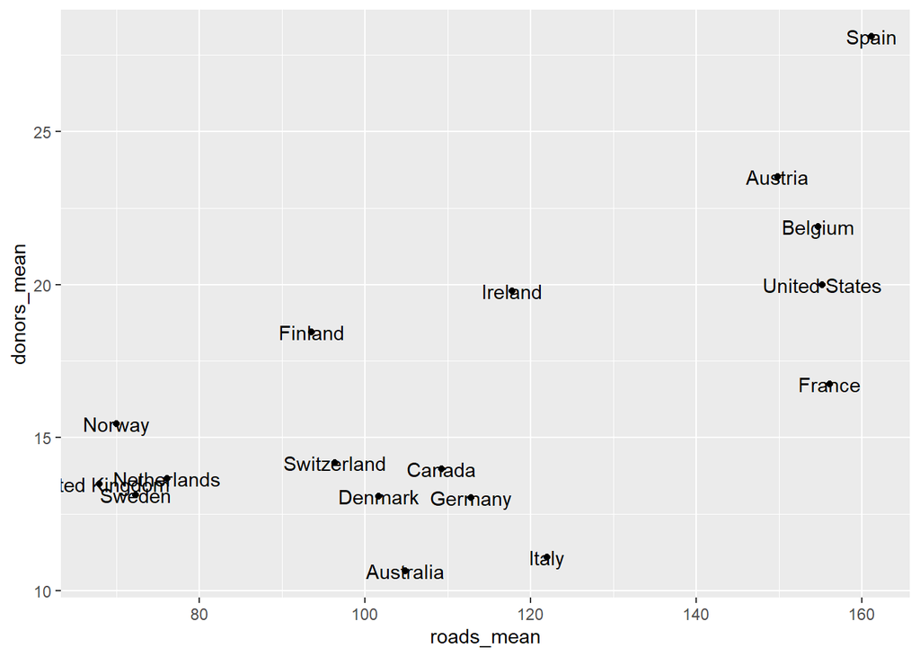

```r
p <- ggplot(data=by_country, mapping=aes(x=roads_mean, y=donors_mean))
p+geom_point() + geom_text(mapping=aes(label=country))
```

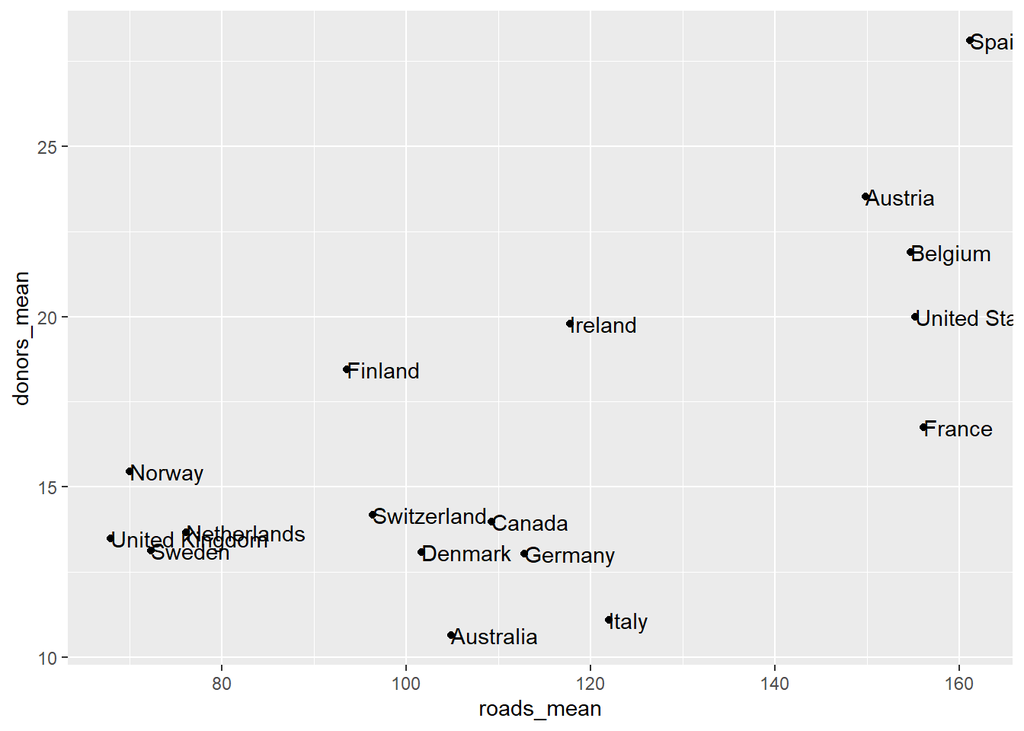

```r
p <- ggplot(data=by_country, mapping =aes(x=roads_mean, y=donors_mean))
p+geom_point() + geom_text(mapping=aes(label=country), hjust=0)
```

```r
library(ggrepel)
```

```r
elections_historic %>% select(2:7)
```

```
## # A tibble: 49 × 6
##     year winner                 win_party ec_pct popular_pct popular_margin
##    <int> <chr>                  <chr>      <dbl>       <dbl>          <dbl>
##  1  1824 John Quincy Adams      D.-R.      0.322       0.309        -0.104
##  2  1828 Andrew Jackson         Dem.       0.682       0.559         0.122
##  3  1832 Andrew Jackson         Dem.       0.766       0.547         0.178
##  4  1836 Martin Van Buren       Dem.       0.578       0.508         0.142
##  5  1840 William Henry Harrison Whig       0.796       0.529         0.0605
##  6  1844 James Polk             Dem.       0.618       0.495         0.0145
##  7  1848 Zachary Taylor         Whig       0.562       0.473         0.0479
##  8  1852 Franklin Pierce        Dem.       0.858       0.508         0.0695
##  9  1856 James Buchanan         Dem.       0.588       0.453         0.122
## 10  1860 Abraham Lincoln        Rep.       0.594       0.396         0.101
## # ℹ 39 more rows
```

```r
p_title <- "Presidential Elections: Popular & Electoral College Margins"
p_subtitle <- "1824-2016"
p_caption <- "Data for 2016 are provisional."
```

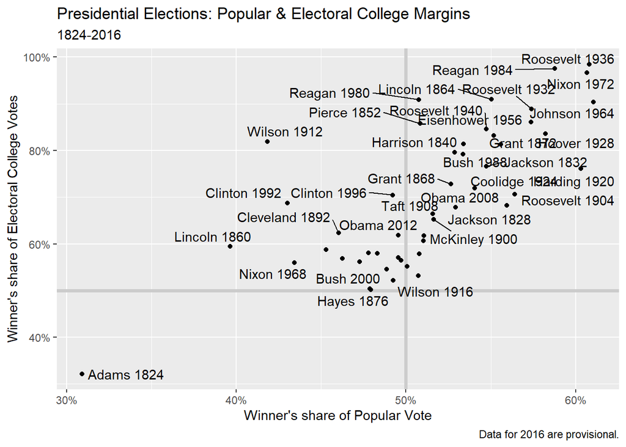

```r
library(ggplot2)
library(ggrepel)
library(scales)

x_label <- "Winner's share of Popular Vote"
y_label <- "Winner's share of Electoral College Votes"

p <- ggplot(elections_historic, aes(x = popular_pct, y = ec_pct, label = winner_label))

p + geom_hline(yintercept = 0.5, size = 1.4, color = "gray80") +
  geom_vline(xintercept = 0.5, size = 1.4, color = "gray80") +
  geom_point() +
  geom_text_repel() +
  scale_x_continuous(labels = percent) +
  scale_y_continuous(labels = percent) +
  labs(x = x_label, y = y_label, title = p_title, subtitle = p_subtitle, caption = p_caption)
```

# 4 Label Outliers

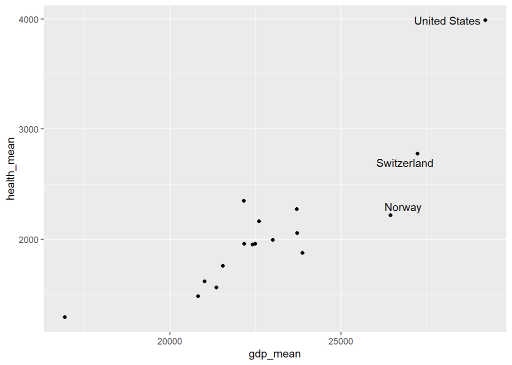

```r
p<-ggplot(data=by_country, mapping=aes(x=gdp_mean, y=health_mean))

p+geom_point()+
  geom_text_repel(data=subset(by_country, gdp_mean>25000), mapping = aes(label=country))
```

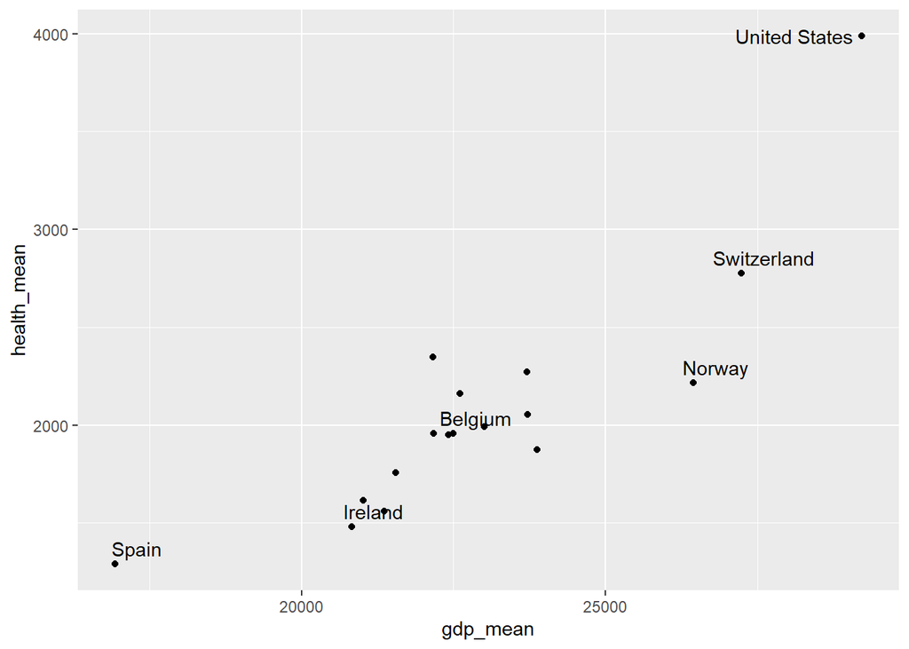

```r
p<-ggplot(data=by_country, mapping=aes(x=gdp_mean, y=health_mean))

p+geom_point()+
  geom_text_repel(data=subset(by_country, gdp_mean>25000 | health_mean <1500| country %in% "Belgium"), mappin = aes(label=country))
```

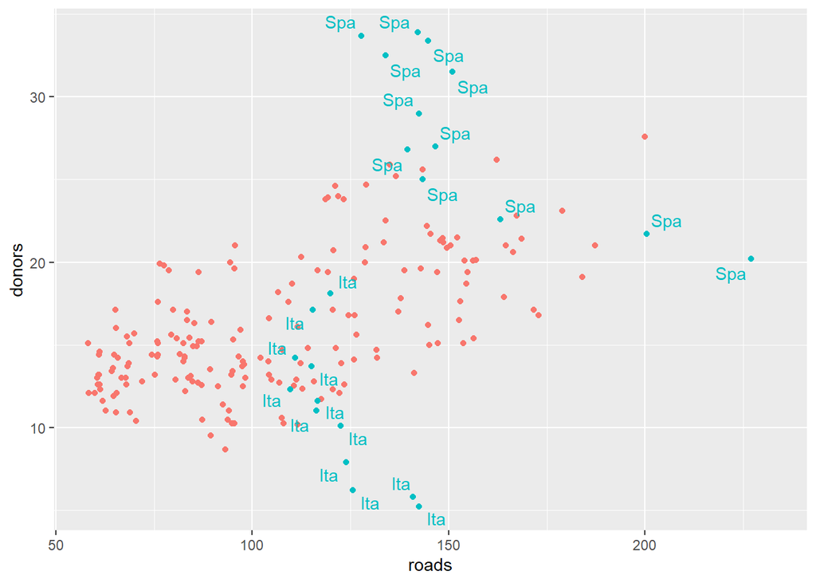

```r
organdata$ind <- organdata$ccode %in% c("Ita","Spa") & organdata$year >1998

p <- ggplot(data=organdata, mapping= aes(x=roads, y=donors, color=ind))

p+geom_point()+ geom_text_repel(data=subset(organdata, ind), mapping = aes(label=ccode)) + guides(label=FALSE, color=FALSE)
```

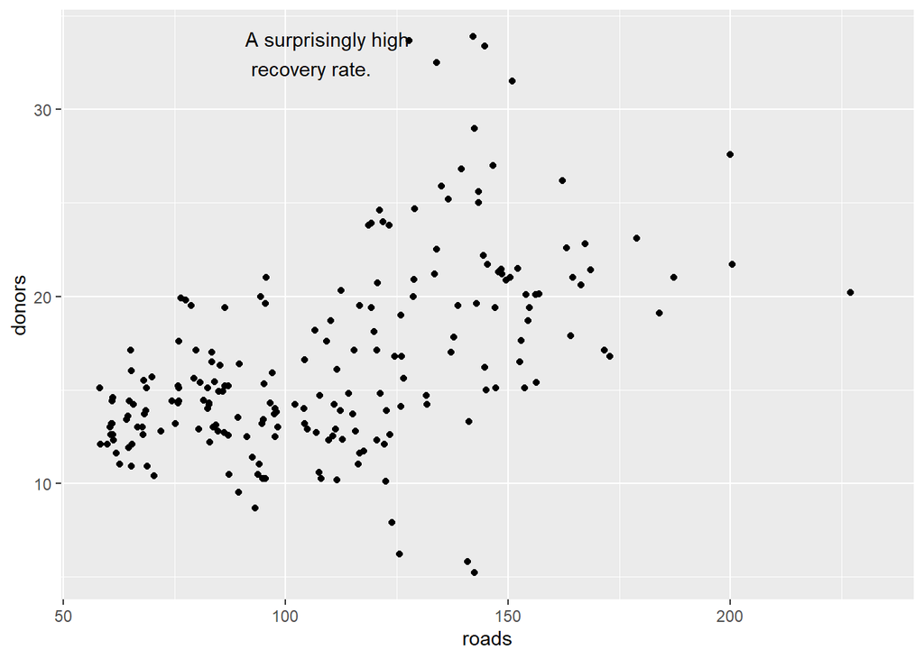

```r
p <- ggplot(data=organdata, mapping= aes(x=roads, y=donors))

p+geom_point()+ annotate(geom="text", x=91, y=33, label="A surprisingly high \n recovery rate.", hjust=0)
```

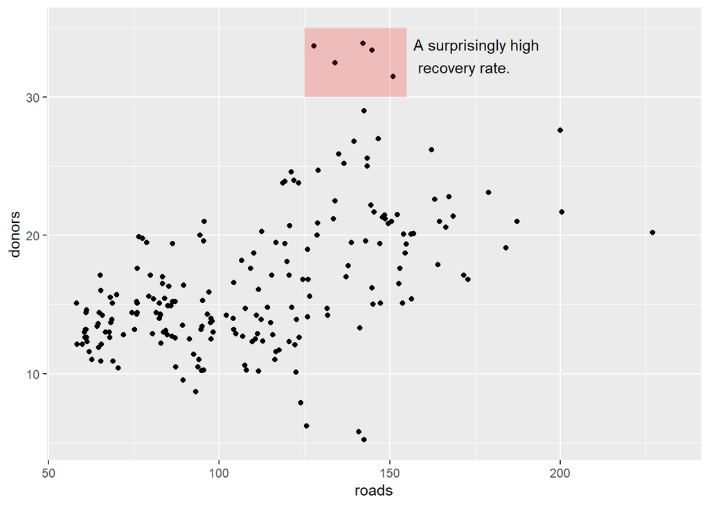

```r
p <- ggplot(data=organdata, mapping=aes(x=roads, y=donors))
p+geom_point() + annotate(geom="rect", xmin=125,xmax=155, ymin=30, ymax=35, fill="red", alpha=0.2)+ annotate(geom="text", x=157, y=33, label = "A surprisingly high \n recovery rate.", hjust=0)
```

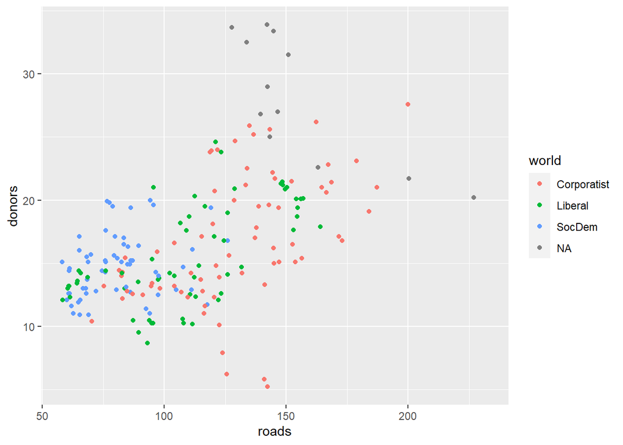

```r
p<- ggplot(data=organdata, mapping=aes(x=roads, y=donors, color=world))
p+geom_point()
```

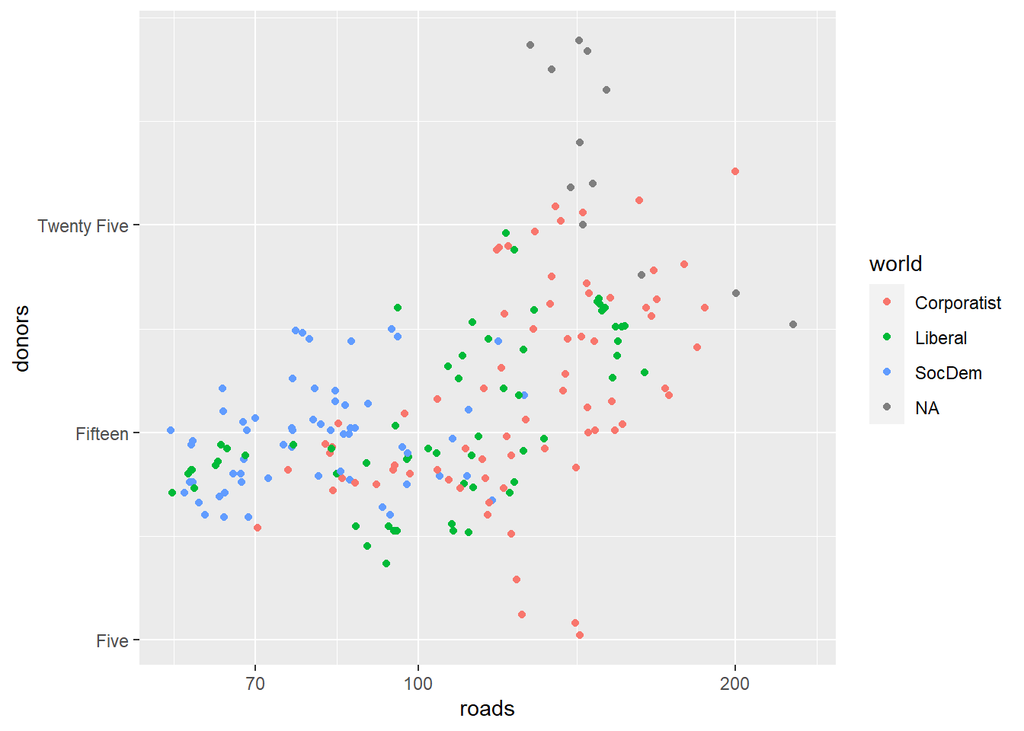

```r
p <- ggplot(data=organdata, mapping=aes(x=roads, y=donors, color=world))

p+geom_point() + scale_x_log10() + scale_y_continuous(breaks=c(5,15,25), labels = c("Five", "Fifteen", "Twenty Five"))
```

[figure not shown]

```r
p <- ggplot(data=organdata, mapping=aes(x=roads, y=donors, color=world))

p+ geom_point()+scale_color_discrete(labels=c("Corporalist", "Liberal", "Social Democratic", "Unclassified")) + labs(x="Road Deaths", y="Donor Procurement", color= "Welfare State")
```

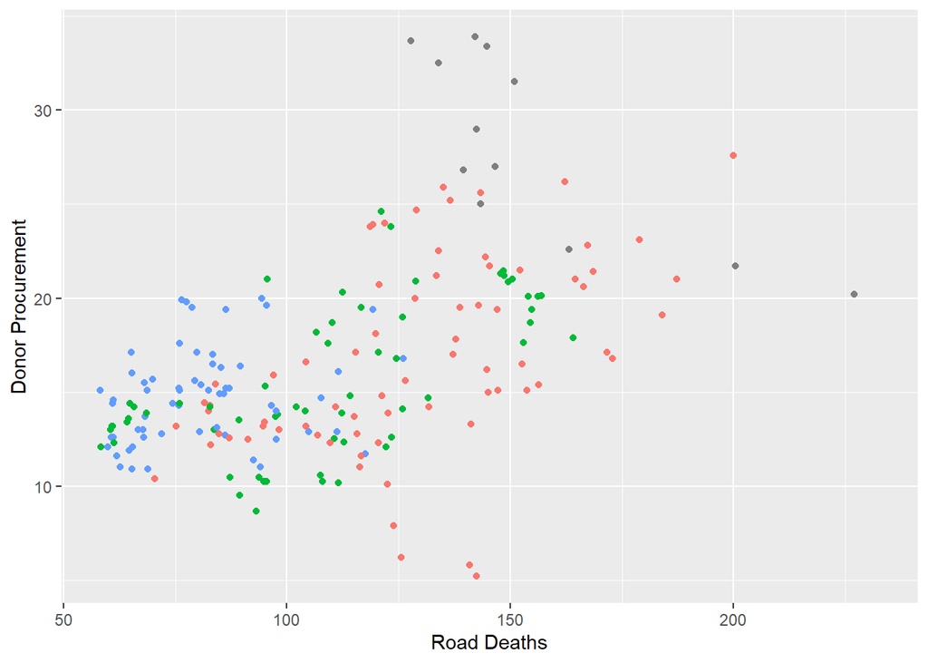

```r
p <- ggplot(data=organdata, mapping=aes(x=roads, y=donors, color=world))

p+ geom_point()+ labs(x="Road Deaths", y="Donor Procurement") + guides(color=FALSE)
```

```r
gss_sm %>% group_by(race, degree) %>% summarize (N=n()) %>%
  mutate(pct=round(N/sum(N)*100,0))
```

```
## # A tibble: 18 × 4
## # Groups:   race [3]
##    race  degree             N   pct
##    <fct> <fct>          <int> <dbl>
##  1 White Lt High School   197     9
##  2 White High School     1057    50
##  3 White Junior College   166     8
##  4 White Bachelor         426    20
##  5 White Graduate         250    12
##  6 White <NA>               4     0
##  7 Black Lt High School    60    12
##  8 Black High School      292    60
##  9 Black Junior College    33     7
## 10 Black Bachelor          71    14
## 11 Black Graduate          31     6
## 12 Black <NA>               3     1
## 13 Other Lt High School    71    26
## 14 Other High School      112    40
## 15 Other Junior College    17     6
## 16 Other Bachelor          39    14
## 17 Other Graduate          37    13
## 18 Other <NA>               1     0
```

# 5 Modificações autorais

```r
elections_historic
```

```
## # A tibble: 49 × 19
##    election  year winner      win_party ec_pct popular_pct popular_margin  votes
##       <int> <int> <chr>       <chr>      <dbl>       <dbl>          <dbl>  <int>
##  1       10  1824 John Quinc… D.-R.      0.322       0.309        -0.104  1.13e5
##  2       11  1828 Andrew Jac… Dem.       0.682       0.559         0.122  6.43e5
##  3       12  1832 Andrew Jac… Dem.       0.766       0.547         0.178  7.03e5
##  4       13  1836 Martin Van… Dem.       0.578       0.508         0.142  7.63e5
##  5       14  1840 William He… Whig       0.796       0.529         0.0605 1.28e6
##  6       15  1844 James Polk  Dem.       0.618       0.495         0.0145 1.34e6
##  7       16  1848 Zachary Ta… Whig       0.562       0.473         0.0479 1.36e6
##  8       17  1852 Franklin P… Dem.       0.858       0.508         0.0695 1.61e6
##  9       18  1856 James Buch… Dem.       0.588       0.453         0.122  1.84e6
## 10       19  1860 Abraham Li… Rep.       0.594       0.396         0.101  1.86e6
## # ℹ 39 more rows
## # ℹ 11 more variables: margin <int>, runner_up <chr>, ru_part <chr>,
## #   turnout_pct <dbl>, winner_lname <chr>, winner_label <chr>, ru_lname <chr>,
## #   ru_label <chr>, two_term <lgl>, ec_votes <dbl>, ec_denom <dbl>
```

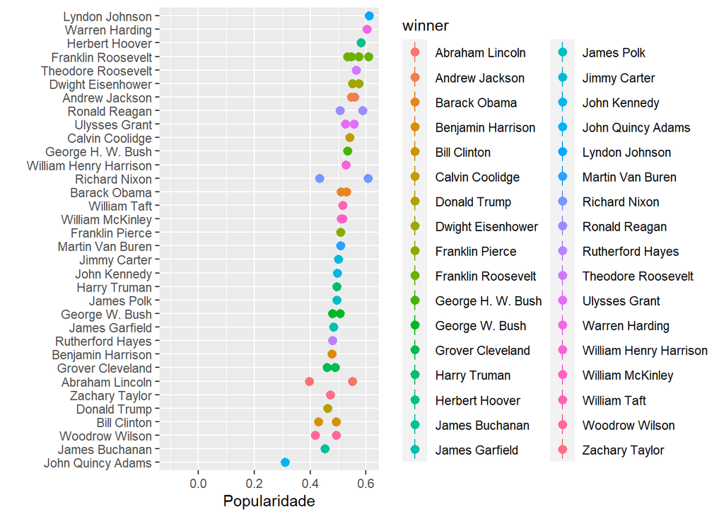

```r
p <- ggplot(data = elections_historic, mapping = aes(x = reorder(winner, popular_pct), y = popular_pct))

p + geom_pointrange(mapping = aes(ymin = popular_margin, ymax = popular_margin, color = winner)) +
  labs(x = "", y = "Popularidade")  + coord_flip()
```

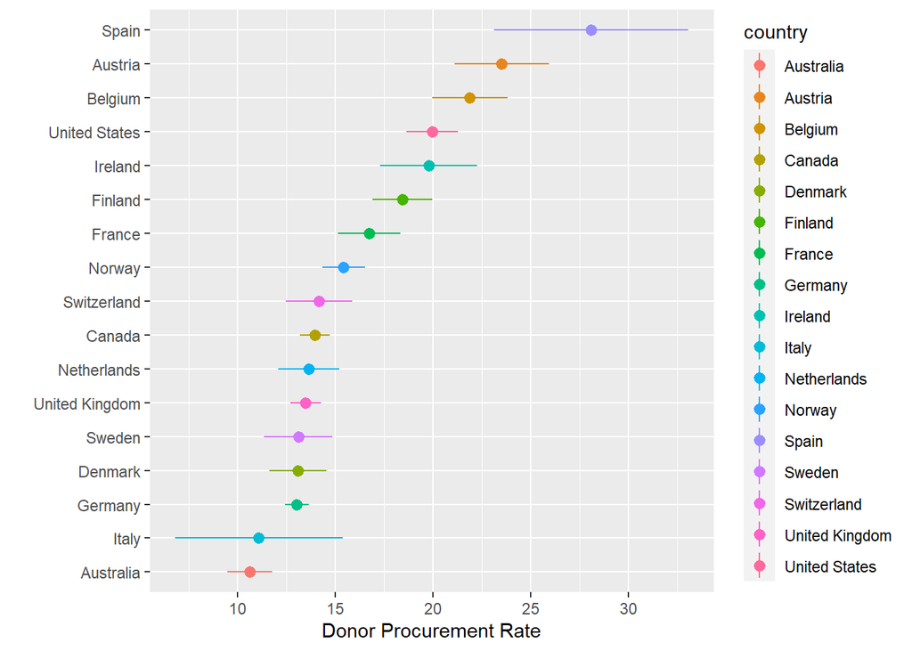

```r
p <- ggplot(data = by_country, mapping = aes(x = reorder(country, donors_mean), y = donors_mean))

p + geom_pointrange(mapping = aes(ymin = donors_mean - donors_sd, ymax = donors_mean + donors_sd, color = country)) +
  labs(x = "", y = "Donor Procurement Rate") + coord_flip()
```